# Presentación de modelos en Análisis de Sentimientos

## CNN

```python
filters = 250
kernel_size = 3
hidden_dims = 250

cnn = Sequential([
    Embedding(vocab_size, embedding_size, input_length=max_words),
    Dropout(0.2),
    Conv1D(filters,kernel_size,padding='valid', activation='relu', strides=1),
    GlobalMaxPooling1D(),
    Dense(hidden_dims),
    Dropout(0.2),
    Activation('relu'),
    Dense(1),
    Activation('sigmoid')
])

print(cnn.summary())
```

```
Model: "sequential_6"
_________________________________________________________________
Layer (type)                 Output Shape              Param #
=================================================================
embedding_12 (Embedding)     (None, 500, 64)           320000
_________________________________________________________________
dropout_4 (Dropout)          (None, 500, 64)           0
_________________________________________________________________
conv1d_1 (Conv1D)            (None, 498, 250)          48250
_________________________________________________________________
global_max_pooling1d_1 (Glob (None, 250)               0
_________________________________________________________________
dense_9 (Dense)              (None, 250)               62750
_________________________________________________________________
dropout_5 (Dropout)          (None, 250)               0
_________________________________________________________________
activation (Activation)      (None, 250)               0
_________________________________________________________________
dense_10 (Dense)             (None, 1)                 251
_________________________________________________________________
activation_1 (Activation)    (None, 1)                 0
=================================================================
Total params: 431,251
Trainable params: 431,251
Non-trainable params: 0
_________________________________________________________________
None
```

```python
cnn_test_loss, cnn_test_acc = cnn.evaluate(X_test, y_test, verbose=0)
print(f'Test accuracy: {cnn_test_acc*100}')
print(f'Test loss: {cnn_test_loss}')
```

```
Test accuracy: 87.84400224685669
Test loss: 0.6869242787361145
```

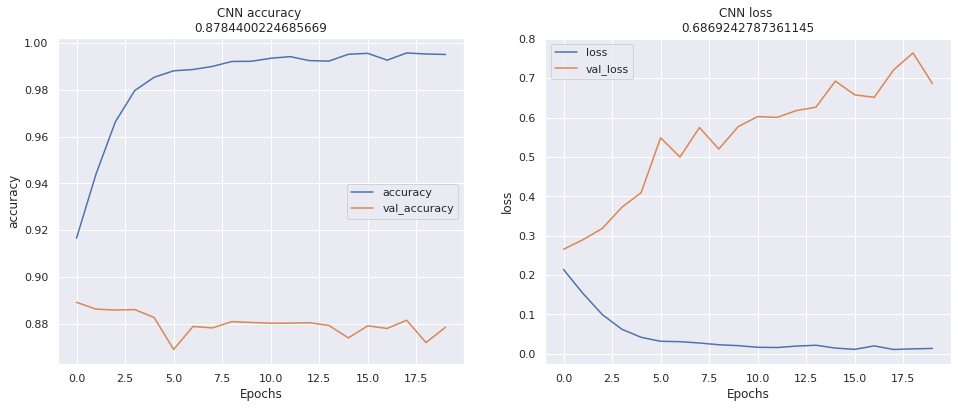

```python
plt.figure(figsize=(16, 6))
plt.subplot(1, 2, 1)
plot_graphs(history_cnn, 'accuracy', f"CNN accuracy \n{cnn_test_acc}")
plt.subplot(1, 2, 2)
plot_graphs(history_cnn, 'loss', f"CNN loss \n{cnn_test_loss}")
```

## Análisis de resultados

| Modelo | Exactitud | Pérdida |
| --- | --- | --- |
| RNN + LSTM | 85.32 | 81.24 |
| RNN + Bidirectional | 86.92 | 69.27 |
| CNN | 87.84 | 68.69 |

- A pesar de que los tres modelos obtienen resultados muy similares en precisión, son los valores de pérdida los que más varían para una RNN con LSTM
- Lo que sorprende de los resultados es que el modelo de redes convolucionales (CNN) sea el mejor de los tres, esto debido a que las redes recurrentes (RNN) ocupando celdas LSTM o Bidireccionales, fueron diseñados para información secuencial (como texto) y deberían funcionar de mejor manera puesto que pasan información entre cada iteración haciendo uso del estado oculto $h_t$

## 3. BERT

* En realidad utilicé DistilBERT pues ofrece un rendimiento muy similar a BERT (95\% similar) y utiliza 40\% menos parámetros

## Procesamiento de datos - Tokenización

```python
from transformers import AutoTokenizer

checkpoint = "distilbert-base-cased"
tokenizer = AutoTokenizer.from_pretrained(checkpoint)
tokenized_sentences_1 = tokenizer(raw_datasets["train"]["text"])
```

```
Token indices sequence length is longer than the specified maximum sequence length for this model (521 > 512). Running this sequence through the model will result in indexing errors
```

```python
tokenized_dataset = tokenizer(
    raw_datasets["train"]["text"],
    padding=True,
    truncation=True,
)
```

```python
tokenized_datasets = raw_datasets.map(tokenize_function, batched=True)
tokenized_datasets
```

```
DatasetDict({
    train: Dataset({
        features: ['text', 'label', 'input_ids', 'attention_mask'],
        num_rows: 25000
    })
    test: Dataset({
        features: ['text', 'label', 'input_ids', 'attention_mask'],
        num_rows: 25000
    })
    unsupervised: Dataset({
        features: ['text', 'label', 'input_ids', 'attention_mask'],
        num_rows: 50000
    })
})
```

```python
from transformers import DataCollatorWithPadding

data_collator = DataCollatorWithPadding(tokenizer=tokenizer)
```

## Fine Tuning

Primero, hay que la clase `TrainingArguments` la cual contendrá todos los hiperparámetros que utilizaremos en `Trainier` para el entrenamiento y evaluación

```python
from transformers import TrainingArguments

training_args = TrainingArguments("test-trainer", evaluation_strategy="epoch")
```

Ahora, definimos el modelo a partir del `checkpoint` y la clase para clasificación de textos: `AutoModelForSequenceClassification`

```python
from transformers import AutoModelForSequenceClassification

model = AutoModelForSequenceClassification.from_pretrained(checkpoint, num_labels=2)
```

[output not shown]

```python
from transformers import Trainer

trainer = Trainer(
    model,
    training_args,
    train_dataset=tokenized_datasets["train"],
    eval_dataset=tokenized_datasets["test"],
    data_collator=data_collator,
    tokenizer=tokenizer,
    compute_metrics=compute_metrics,
)
```

```python
trainer.train()
```

```
The following columns in the training set  don't have a corresponding argument in `DistilBertForSequenceClassification.forward` and have been ignored: text. If text are not expected by `DistilBertForSequenceClassification.forward`,  you can safely ignore this message.
***** Running training *****
  Num examples = 25000
  Num Epochs = 3
  Instantaneous batch size per device = 8
  Total train batch size (w. parallel, distributed & accumulation) = 8
  Gradient Accumulation steps = 1
  Total optimization steps = 9375
Automatic Weights & Biases logging enabled, to disable set os.environ["WANDB_DISABLED"] = "true"
```

[9375/9375 48:32, Epoch 3/3]

| Epoch | Training Loss | Validation Loss | Accuracy |
| --- | --- | --- | --- |
| 1 | 0.169000 | 0.396789 | 0.900760 |
| 2 | 0.108000 | 0.427939 | 0.911160 |
| 3 | 0.031300 | 0.528995 | 0.915600 |

[output not shown]

[output cut: 50 more lines]

[output not shown]

```
TrainOutput(global_step=9375, training_loss=0.12273384012858073, metrics={'train_runtime': 2912.7831, 'train_samples_per_second': 25.749, 'train_steps_per_second': 3.219, 'total_flos': 9418419625622976.0, 'train_loss': 0.12273384012858073, 'epoch': 3.0})
```

## Análisis de Resultados

Podemos observar que tan solo despues de realizar 3 epocas de entrenamiento, DistilBERT (versien reducida y mas eficiente que BERT), obtiene una precision de 91.5%, sin embargo, el tiempo de entrenamiento fue 48 minutos:

| Epoch | Training Loss | Validation Loss | Accuracy |
| --- | --- | --- | --- |
| 1 | 0.16900 | 0.3967 | 0.900760 |
| 2 | 0.10800 | 0.4279 | 0.911160 |
| 3 | 0.031300 | 0.5289 | 0.915600 |

## 4. Conclusiones

Para esta tarea, el mejor modelo fue BERT, llegando a una exactitud de 91.56\% con tan solo 3 épocas de entrenamiento:

| Modelo | Exactitud | Tiempo de entrenamiento |
| --- | --- | --- |
| Regresión Logística + Promedio de vectores de palabras | 0.51 | < 1 min |
| Regresión Logística + Doc2Vec | 0.55 | < 1 min |
| Regresión Logística + SentenceBERT | 0.58 | < 1 min |
| CNN | 0.8784 | ~15-20 min |
| RNN + LSTM | 0.8532 | ~15-20 min |
| RNN + Bidirectional | 0.8692 | ~15-20 min |
| BERT | 0.9156 | ~ 50 min |

Sin embargo, el tiempo de cómputo requerido es mucho mayor que contra modelos de machine learning tradicionales